# Homework #10

Jules Ford

2023-04-19

**Problem 1**

```r
vec <- c(8, 4, 0, 10, 900, 4, 0)

####################################
# FUNCTION: zeroCalculator
# packages: none
# purpose: determine the number of zeros inside a numeric vector
# input: a numeric vector
# output: the number of zeros inside the numeric vector
#----------------------------
crazyZeroCalculator <- function(vec) {
  counter <- 0
  betterVec <- paste(vec, collapse="")
  betterVec <- strsplit(betterVec, split="")
  for (i in seq_along(betterVec[[1]])) {
    if (betterVec[[1]][i] == "0") {
     counter <- counter + 1
    }
  }
  return(counter)
}

check <- crazyZeroCalculator(vec)
print(check)
```

```
## [1] 5
```

This problem requires us to take a vector and determine the number of zeroes in that vector. To make this function, I used the `paste()` function so I could collapse the vector into a single character string with no spaces. Then, I used the `strsplit()` function to separate each character from that string into its own character string object. Then, using a for loop, I checked whether that object was the character string `"0"` and if it was, I added 1 to the counter variable (the running total of zeroes in that vector).

**Problem 2**

```r
newVec <- c(8, 4, 0, 10, 900, 4, 0, 0, 20)

####################################
# FUNCTION: shortZeroCalc
# packages: none
# purpose: use subsetting to determine whether each value in a vector contains at least one 0
# input: a numeric vector
# output: the number of items inside the numeric vector that contain at least one 0
#----------------------------
shortZeroCalc <- function(vector) {
  return(length(vector[vector %% 10 == 0]))
}

numOfZeroes <- shortZeroCalc(newVec)
numOfZeroes
```

```
## [1] 6
```

This problem tasks us with shortening our first answer into by using subsetting rather than looping to accomplish the same task. In the first problem I went the trickier route of building a function that could count every single zero (so it could detect that 900 had two 0s). In simplifying this version, because I didn’t go the same route of turning everything into character strings, I settled for the counter being able to detect whether a given item had at least one 0.

**Problem 3**

```r
####################################
# FUNCTION: matrixMaker
# packages: none
# purpose: generate a matrix given its row and column
# input: 2 integers, reprsenting rows and columns in a matrix
# output: a matrix with the inputted dimensions, where each element is the product of the given row and column number
#----------------------------
matrixMaker <- function(rows, cols) {
  mat <- matrix(data=NA, nrow=rows, ncol=cols) # this makes the matrix
  for (i in 1:nrow(mat)) {
    for (j in 1:ncol(mat)) { # I'm going to loop through each row and column
      mat[i,j] <- (i * j) # and assign the product of that point in the loop (i represents the row # and j represents the column #)
    }
  }
  return(mat)
}

test <- matrixMaker(8,4)
print(test)
```

```
##      [,1] [,2] [,3] [,4]
## [1,]    1    2    3    4
## [2,]    2    4    6    8
## [3,]    3    6    9   12
## [4,]    4    8   12   16
## [5,]    5   10   15   20
## [6,]    6   12   18   24
## [7,]    7   14   21   28
## [8,]    8   16   24   32
```

This problem tasks us with making a function that generates a matrix based on an input amount of rows and columns, where we have to fill each part of the matrix with the product of the row and column. To accomplish this, I used a for loop to iterate through each row and column in the matrix. For each part of the matrix, I multiplied the row and column number (denoted by i and j within the loop) to get the proper product!

**Problem 4** This series of problems is all about randomization tests.

**4a**

```r
####################################
# FUNCTION: dfMaker
# packages: none
# purpose: generate data frame for 3 groups of data drawn from a distribution with a different mean
# input: 3 mean values
# output: the dataframe
#----------------------------
library(tidyverse)
dfMaker <- function(mean1,mean2,mean3) {
  group1 <- data.frame("Group"="Group1","Response"=rnorm(10,mean=mean1,sd=0.4))
  group2 <- data.frame("Group"="Group2","Response"=rnorm(10,mean=mean2,sd=0.4))
  group3 <- data.frame("Group"="Group3","Response"=rnorm(10,mean=mean3,sd=0.4))
  df <- rbind(group1,group2,group3)
  return(df)
  #response
}

myDF <- dfMaker(3, 5, 18)
print(myDF)
```

```
##     Group  Response
## 1  Group1  2.895830
## 2  Group1  3.167642
## 3  Group1  3.780199
## 4  Group1  3.218415
## 5  Group1  2.890959
## 6  Group1  3.478577
## 7  Group1  2.684229
## 8  Group1  3.127348
## 9  Group1  2.877149
## 10 Group1  3.221826
## 11 Group2  4.956490
## 12 Group2  5.387517
## 13 Group2  5.277023
## 14 Group2  4.652338
```

[output cut: 16 more lines]

This part of the problem asks us to generate a data frame for 3 groups varying in means. I decided to make a function that took in mean values for each group and produced 3 data frames with the `data.frame()` function and generates data for the response column with the `rnorm()` function for each group. Then, I used the `rbind()` function to combine the data frames into one master data frame containing all the groups and their responses.

**4b**

```r
####################################
# FUNCTION: dfShuffler
# packages: none
# purpose: Reshuffle response variable from prior df, find mean for each group in the new df, and return those means in a vector with 3 objects
# input: the dataframe from the prior problem
# output: a vector with the means
#----------------------------
dfShuffler <- function(DF) {
  shuffledDF <- data.frame("theGroups"=DF$Group,"ShuffledVals"=sample(DF$Response)) # this shuffles the DF
  byGroup <- group_by(shuffledDF, theGroups)
  meanFinder <- summarize(byGroup, meanData = mean(ShuffledVals))
  g1 <- meanFinder[[1,2]]
  g2 <- meanFinder[[2,2]]
  g3 <- meanFinder[[3,2]]
  meanVec <- c(g1, g2, g3)
  return(meanVec)
}

meansVector <- dfShuffler(myDF)
print(meansVector)
```

```
## [1] 9.739644 9.878781 6.630464
```

This part of the problem required us to shuffle the data, calculate the means for each group for the shuffled data, and to store those data in a vector. To do this, I first shuffled the values in the Response column with the `sample()` function. Then, I used the `group_by()` and `summarize()` functions to sort the data by group and determine the means for each group. I assigned the mean for each group to a variable and passed those variables into the vector that gets returned at the end of the function.

**4c**

```r
####################################
# FUNCTION: hundredLoop
# packages: none
# purpose: Use a for loop to go through the code in 4b 100 times, storing the means into a new DF
# input: the DF from 4a
# output: a new DF with Replicate #, and means calculated for each of the 100 trials
#----------------------------
hundredLoop <- function(DF) {
  emptyDF <- data.frame("Replicate"=1:100, "G1 mean"=NA, "G2 mean"=NA, "G3 mean"=NA) # this makes a new empty data frame with replicate numbers 1-100 and empty values for each of the groups that will fill over time
  for (i in 1:100) {
    shuffler <- data.frame("theGroups"=DF$Group,"Shuffling"=sample(DF$Response))
    byGroup <- group_by(shuffler, theGroups)
    meanFinder <- summarize(byGroup, meanData = mean(Shuffling))
    g1 <- meanFinder[[1,2]]
    g2 <- meanFinder[[2,2]]
    g3 <- meanFinder[[3,2]]
    emptyDF[i,2] <- g1
    emptyDF[i,3] <- g2
    emptyDF[i,4] <- g3
  }
  return(emptyDF)
}

manyLoops <- hundredLoop(myDF)
print(manyLoops)
```

```
##     Replicate   G1.mean   G2.mean   G3.mean
## 1           1  6.892609  8.574797 10.781483
## 2           2  7.994145  9.930546  8.324197
## 3           3  9.607054  8.054889  8.586946
## 4           4  5.592469  9.383116 11.273304
## 5           5  8.020514  8.272861  9.955515
## 6           6  8.582522  7.887671  9.778695
## 7           7  7.201476 12.360185  6.687228
## 8           8  5.357179 12.936510  7.955200
## 9           9  8.451028  9.584291  8.213570
## 10         10  9.459237 11.596089  5.193563
## 11         11  6.870919  8.328231 11.049739
## 12         12  5.318247 11.019552  9.911091
## 13         13  7.039843  8.228201 10.980845
## 14         14  8.197836  9.610396  8.440657
```

[output cut: 86 more lines]

This problem challenges us to make a for loop to iterate the code in #4b 100 times. To do this, I started by using the `data.frame()` function to make an empty data frame that I’d eventually store the values in (in its leftmost column I had it count from 1-100 for each replicate). Then, I set up a for loop that would shuffle the data in the response column, sort the data by the group number, find the mean, and assign it to its corresponding space in the empty data frame.

**4d**

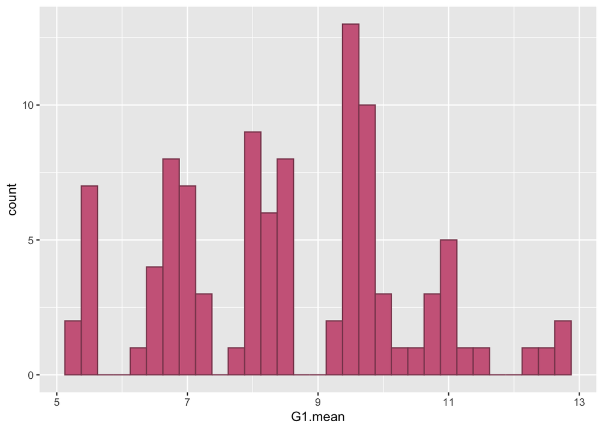

```r
G1hist <- ggplot(manyLoops, aes(x=G1.mean)) + geom_histogram(binwidth=0.25,fill="palevioletred3",color="palevioletred4")
print(G1hist)
```

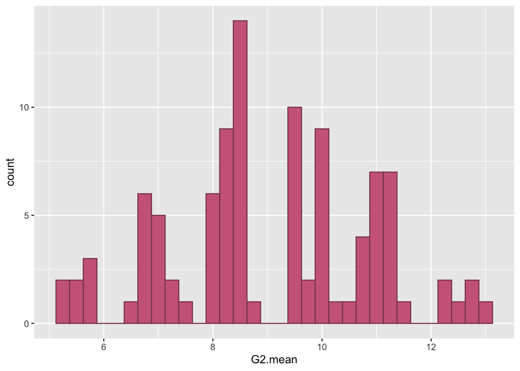

```r
G2hist <- ggplot(manyLoops, aes(x=G2.mean)) + geom_histogram(binwidth=0.25,fill="palevioletred3",color="palevioletred4")
print(G2hist)
```

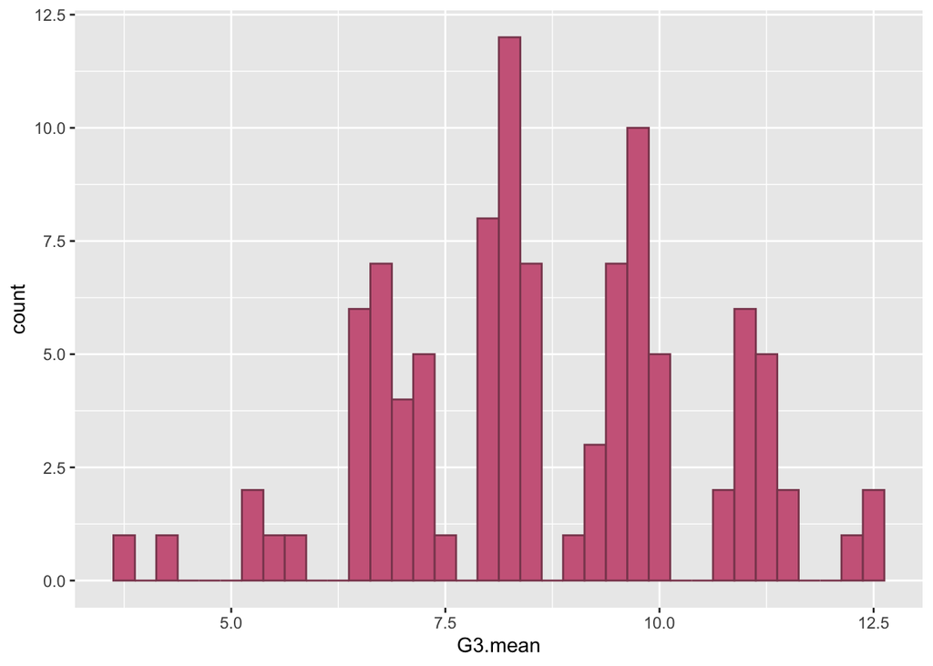

```r
G3hist <- ggplot(manyLoops, aes(x=G3.mean)) + geom_histogram(binwidth=0.25,fill="palevioletred3",color="palevioletred4")
print(G3hist)
```

The final part of the problem tasks us with generating histograms for each of the groups of means for the reshuffled values. Afterward, we need to compare these histograms with the means generated from the originally shuffled groups.

Since I’m running these every time I knit (just to show code is working and everything) the means written down here will be different values from what shows up on the site. These were from a prior time that I ran the code but I think a lot of my findings will remain consistent:

For Group 1, the mean was 7.704529. Most of the means were from 6-11, so it seems consistent. For Group 2, the mean was 11.131424. The histogram showed a lot of means for Group 2 that were below 11, which makes sense because the data from the other groups (when shuffled) was on the lower side. Finally, for Group3, the mean was 7.008356. The data shown in the histogram are generally higher than that, which makes sense because some of the shuffled data would likely increase the means for the group when the data are shuffled together!